# Topicos Estatísticos-Final

joseferson da silva barreto

27/01/2022

# Objetivo

Através do processamento e análise dos dados, definir um modelo que seja capaz de classificar os Aprovados e Negados para o Cartão de Crédito, para esta análise foi otilizado o banco de dados fornecido pela empresa , para realização da análise exploratória foi utilizada a linguagem Python , demais testes e análises foi utlizada a linguagem R ,além do software R/Studio .

# Análise Descritiva

# Descrição

Nessa etapa precisamos transformar as variáveis para utilizá-las nos modelos de Machine Learning. Teremos as seguintes etapas

Eliminar as variáveis que não serão utilizadas;

Identificação de dados missing;

Separação das variáveis categóricas, numéricas e resposta;

Processamento variáveis categóricas;

Processamento variáveis numéricas.

## Tratamentos dos Dados

Como o nosso modelo será criado na linguagem R , o tratamento dos dados também ocorrerá na linguagem R , mas eu poderia executar o procedimento em linguagem python e depois chamar os dados tratados para utilizar na linguegem R.

## Carregando os Dados em Linguagem R

Abaixo já estamos carregando os dados e executando o tratamento das variável citada acima , no Script abaixo tem uma breve descrição de cada procedimento .

```r
library(rpart)






# Criando o modelo
#?rpart
#?rpart.control

library(randomForest)
library(rpart)

#glimpse(dados)


library(plyr)
library(readr)
library(dplyr)
library(caret)
```

```r
library(rpart)
library(rpart.plot)
credit<-read.csv("creditnovo.csv")



credit<-credit[-1]




#removendo a coluna idade
#dados<- dados[,names(dados) != "Idade"]

#arranjando  os dados pela coluna socio
credit <- credit %>% arrange(credit$Socio)

#   covertendo  a variavel socio em
credit$Socio[credit$Socio==0]<-"nao"
credit$Socio[credit$Socio==1]<- "sim"


glimpse(credit)
```

```
## Rows: 2,015
## Columns: 10
## $ Sexo                 <chr> "M", "M", "F", "M", "M", "F", "F", "F", "M", "M",…
## $ Idade                <chr> "22 anos", "23 anos", "24 anos", "24 anos", "25 a…
## $ Escolaridade         <chr> "NAO_INFORMADO", "NAO_INFORMADO", "NAO_INFORMADO"…
## $ statusReceitaFederal <chr> "Regular", "Regular", "Regular", "Regular", "Susp…
## $ CategoriaProfissao   <chr> "TRABALHADORES_DA_PRODUCAO_DE_BENS_E_SERVICOS_IND…
## $ RendaPresumida       <chr> "Ate R$ 1.576,00", "Ate R$ 1.576,00", "Ate R$ 1.5…
## $ Socio                <chr> "não", "não", "não", "não", "não", "não", "não", …
## $ UF                   <chr> "SP", "SP", "PI", "RS", "CE", "CE", "SP", "RJ", "…
## $ Regiao               <chr> "SUDESTE", "SUDESTE", "NORDESTE", "SUL", "NORDEST…
## $ DECISAO_y            <chr> "Aprovado", "Negado", "Negado", "Aprovado", "Nega…
```

```r
#View(dados)
```

Nesse primeiro momento ainda não irei remover os outliers , esses serão os passos mais adiante

## Verificando 2 atributos do cliente

```r
table(credit$Sexo)
```

```
##
##    F    I    M
##  820   55 1140
```

```r
table(credit$Escolaridade)
```

```
##
##                    1º grau completo (ensino fundamental)
##                                                       90
##                          2º grau completo (ensino médio)
##                                                      695
##                        2º grau incompleto (ensino médio)
##                                                      105
##        4ª série completa do 1º grau (ensino fundamental)
##                                                       10
## 5ª a 8ª série incompleta do 1º grau (ensino fundamental)
##                                                       50
##  Até 4ª série incompleta do 1º grau (ensino fundamental)
##                                                       25
##                                            NAO_INFORMADO
##                                                      655
##                             Pós-Graduação/Especialização
##                                                       10
##                                        Superior Completo
##                                                      290
##                                      Superior Incompleto
##                                                       85
```

## Verificando as características do crédito

```r
table(credit$RendaPresumida)
```

```
##
##               Ate R$ 1.576,00  De R$ 1.576,01 a R$ 3.152,00
##                          1090                           470
##  De R$ 3.152,01 a R$ 7.888,00 De R$ 7.888,01 a R$ 15.760,00
##                           225                            95
##                     sem renda
##                           135
```

```r
table(credit$statusReceitaFederal)
```

```
##
##  Regular Suspensa
##     2000       15
```

## Verificando 2 atributos do cliente

```r
table(credit$Idade)
```

```
##
## 19 anos 21 anos 22 anos 23 anos 24 anos 25 anos 26 anos 27 anos 28 anos 29 anos
##      10      10      20      30      35      45      20      35      30      35
## 30 anos 31 anos 32 anos 33 anos 34 anos 35 anos 36 anos 37 anos 38 anos 39 anos
##      65      55      20      55      80      95     105      60      75      70
## 40 anos 41 anos 42 anos 43 anos 44 anos 45 anos 46 anos 47 anos 48 anos 49 anos
##      80      70      85     110      40      40      70      55      70      50
## 50 anos 51 anos 52 anos 53 anos 54 anos 55 anos 56 anos 57 anos 58 anos 59 anos
##      25      35       5      30      15      25      30      35      25      40
## 60 anos 61 anos 62 anos 63 anos 64 anos 65 anos 66 anos 70 anos
##      25      25      20      15      15      15      10       5
```

```r
table(credit$Escolaridade)
```

```
##
##                    1º grau completo (ensino fundamental)
##                                                       90
##                          2º grau completo (ensino médio)
##                                                      695
##                        2º grau incompleto (ensino médio)
##                                                      105
##        4ª série completa do 1º grau (ensino fundamental)
##                                                       10
## 5ª a 8ª série incompleta do 1º grau (ensino fundamental)
##                                                       50
##  Até 4ª série incompleta do 1º grau (ensino fundamental)
##                                                       25
##                                            NAO_INFORMADO
##                                                      655
##                             Pós-Graduação/Especialização
##                                                       10
##                                        Superior Completo
##                                                      290
##                                      Superior Incompleto
##                                                       85
```

## Verificando 2 atributos do cliente

```r
credit <-credit %>% filter(Sexo != "I")
#para executar o segundo comando  remova "#"
table(credit$Sexo)
```

```
##
##    F    M
##  820 1140
```

```r
#table(credit$Escolaridade)
```

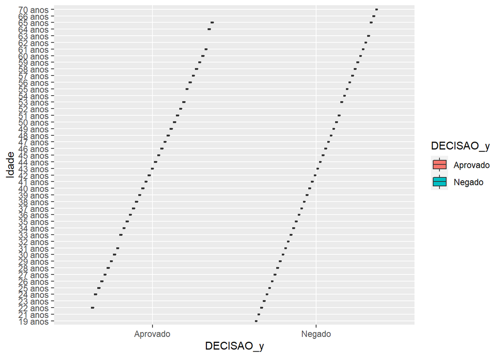

```r
library(ggplot2)
ggplot(data=credit) +
  geom_boxplot(aes(x=DECISAO_y, y=Idade, fill=DECISAO_y))
```

## Transformando idade em variavel qualitativa

para transformar a variável **idade** em qualitativa basta apenas utilizar a função **paste()** adicionando uma string em nossa variável , string= “anos”.

```r
#credit$Idade <-paste(credit$Idade,"anos")
```

Perceba que a variável **idade** agora é uma string(character).

## Verificando Renda Presumida

```r
#table(credit$CategoriaProfissao)
table(credit$RendaPresumida)
```

```
##
##               Ate R$ 1.576,00  De R$ 1.576,01 a R$ 3.152,00
##                          1050                           465
##  De R$ 3.152,01 a R$ 7.888,00 De R$ 7.888,01 a R$ 15.760,00
##                           220                            95
##                     sem renda
##                           130
```

## prosseguindo

```r
table(credit$Socio)
```

```
##
##  não  sim
## 1510  450
```

```r
table(credit$Regiao)
```

```
##
## CENTRO-OESTE     NORDESTE        NORTE      SUDESTE          SUL
##          105          450           40         1205          160
```

Ok! podemos proceguir para a próxima fase .

## Removendo os Outliers da Coluna Idade

Como a arvore de classificação é sensível a outliers , vamos remover os outliers da variável **idade**, para este fim vamos utilizar o comando pipe do pacote **dplyr** os argumentos são adicionados da esquerda para direita (consulte a documentação), ou seja , todo argumento,função que está a esquerda do pipe se desloca para direita ,exemplo : 4 %>% +3 = 7.

Perceba que o 4 foi da direita para a esquerda e depois ocorreu a soma 4+3 .

```r
credit<-credit %>%  arrange(credit$Idade)


# credit <- credit %>% filter(credit$Idade != "20 anos" &  credit$Idade != "71 anos"
#                              &  credit$Idade != "72 anos" &  credit$Idade !="77anos"&
#        credit$Idade !="91 anos")
```

## Transformando 0 em sem renda na coluna renda

```r
credit<-credit %>%  arrange(credit$RendaPresumida)
```

## Removendo os outliers da coluna RendaPresumida

```r
#credit<-filter(credit,credit$RendaPresumida != "Acima de R$ 15.760,01")
```

## Prosseguindo Com os Tratamentos

onde Categoria Profissao for 0 subistituir por “não possui”

```r
credit$CategoriaProfissao[credit$CategoriaProfissao==0]<-"não possui"
```

verificando a coluna socio

```r
table(credit$Socio)
```

```
##
##  não  sim
## 1510  450
```

verificando a coluna UF

```r
table(credit$UF)
```

```
##
##  AL  AM  BA  CE  DF  ES  GO  MA  MG  MS  MT  PA  PB  PE  PI  PR  RJ  RN  RO  RS
##  15  15 165  75  45  40  35  10  75  15  10  15  35  85  10  85 245  35  10  35
##  SC  SE  SP
##  40  20 845
```

Verificando a coluna região

```r
table(credit$Regiao)
```

```
##
## CENTRO-OESTE     NORDESTE        NORTE      SUDESTE          SUL
##          105          450           40         1205          160
```

verificando a variável target

```r
table(credit$DECISAO_y)
```

```
##
## Aprovado   Negado
##     1000      960
```

ok! prosseguindo para criação do modelo

# Salvando o Dataframe Tratado

Mas antes vamos salvar as alterações feitas no arquivo em um novo CSV , coso precise no futuro

```r
library(utils)

# write.csv(credit,"credit.csv",row.names = FALSE)
```

```r
#
credit$vezes<-rep(1,nrow(credit))
```

# carregando pacotes necessários e Criando o Modelo (Modelo 1)

Para criar o modelo de árvore de classificação vamos utilizar o pacote **Rpart** chamando a função **Rpart** que é capaz de criar um particionamento recursivo e uma arvore de regresão , ou seja , uma arvore de classificação ou uma arvore de regresão ,dependendo da variável target(alvo). No nosso caso, a variável target(**DECISAO_y**) é uma categoria , então vamos trabalhar com classificação .

Outra função que será utilizada é a **rpart.control()** que nos permite controlar como a árvore de decisão será criada , o argumento **data** recebe nosso dataframe ,o argumento **method** recebe **“class”** como estamos querendo trabalhar com classificar , para ver outros **method** consulte a documentação .

Em sequência, vamos adicionar o argumento **parms** para fazer a divisão dos nós que pode ser o index **gine** ou **information** que é atrávez do ganho de informação com a entropia , a forma que a árvore séra construida e os nós distribuídos será feita por um índice ou outro ,ou seja , índice **gine** ou **information**. No nosso caso vamos utilizar a entropia , logo vamos utlizar **information** por último chamamos o parâmentro **control** ,nele chamamos a função **rpartcontrol** pra poder colocar uma lista de outros parâmetros , **minsplit** irá divir nossa árvore em subdivisões que desejarmos , no meu caso irei utlizar **minsplit= 2**.

```r
# Carregando o pacote
#install.packages("rpart")
library(rpart)

attach(credit)




# Criando o modelo
#?rpart
#?rpart.control


library(rpart)
attach(credit)
#glimpse(dados)


library(plyr)
library(readr)
library(dplyr)
library(caret)
library(rpart)
library(rpart.plot)

credit$DECISAO_y<-factor(credit$DECISAO_y,levels =c("Aprovado","Negado"))
ind<-createDataPartition(credit$DECISAO_y,p = 0.8,times = 1,list = F)



treino<-credit[ind,]
teste<-credit[-ind,]
# Criando o modelo
creditprev <- rpart(treino$DECISAO_y ~.,
                      data=treino,
                      method = "class",
                      parms = list(split = "information"),
                      control = rpart.control(minsplit = 2))
```